# Party Perception’s Role in Elections

This is an [R Markdown](http://rmarkdown.rstudio.com) Notebook.

# Perception in elections

In 1980 it was competence, leadership in 1984, patriotism in 1988, trustworthiness in 1992 and 1996, integrity and leadership ability in 2000, decisiveness and leadership in 2004, and Knowledge and temperament in 2008—these candidate traits have been deciding factors in elections According to the Inter-university Consortium for Political and Social Research, candidate traits can make or break an election outcome.

While the issues are important to many voters, the images of candidates that voters shape in their minds are heavily influenced by voters’ perception of a candidate’s personal qualities. You’re more likely to vote for a candidate who you think is honest—or what some might call moral—than a candidate you see as untrustworthy. Or, If you’re on the fence you’re likely to select the candidate that you think is a better leader. A voter’s vote for president is a very personal one, and traits play a role in shaping that vote.

The American National Election Studies (ANES) are surveys of voters in the U.S. on a national scale. For each presidential election since 1980, ANES has collected information about the personality traits of presidential candidates, by asking how well 8 personality traits describe republican and democratic candidates. The traits surveyed where Intelligence, Compassion, Decency, Inspiring, Knowledge, Morals, Leadership, and Caring, and respondents could rank each trait on a scale of one to four, one being “Extremely well” and four being “Not well at all.” For this analysis anes_dem, refers to opinions on the democratic candidate, and anes_rep refers to opinions on the republican.

With this data, we explore not only the perceptions of individuals in individual races, but general perceptions by party, how that has changed over time, and what impact that has on voters’ decisions.

## What qualities describe do voters use to describe Democrats and Republicans?

Outside of the candidate, there is first the question of the party as a whole. Turn on Fox News, and you might hear Tucker Carlson describe democrats as “vindictive” — meaning immoral and lacking decency— or “snowflakes’’ — meaning weak or overly sensitive. Switch to MSNBC and you’ll hear about republican “hacks”— lacking leadership and compassion— and “bigots” — missing knowledge and honesty.

But there is a better way to learn about what qualifies to define a party.

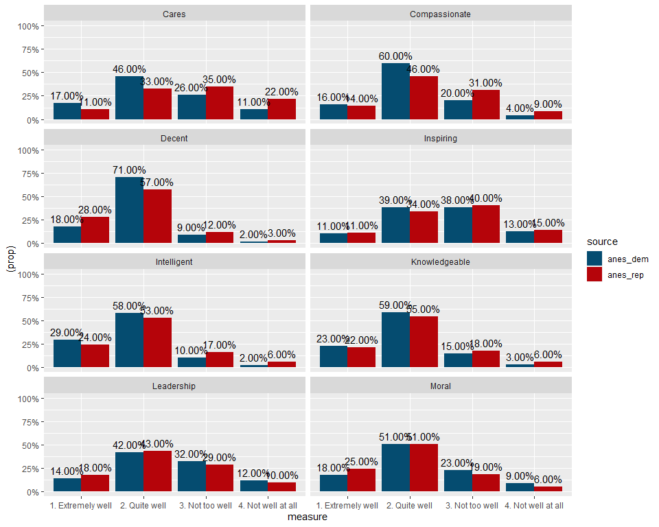

There are some interesting things to note here. A larger percentage of respondents identify democrats, rather than republican candidates, as extremely or quite caring (63 percent of Democrats candidates are ranked this while only 44 percent of Republicans are), compassionate (76 versus 60 percent), and Intelligent (87 versus 77 percent).

Whereas republicans beat out democrats, in leadership (61 versus 55 percent) and morals (76 versus 68). You’ll notice that these margins are much more narrow than those that are democratic lead.

This visualization allows a less partisan way than cable news to think about how characteristics define different parties. And some of the takeaways make a lot of sense considering what is known about the party breakdown of the United States. Take the trait “inspiring” for example, inspiration ability is incredibly objective, but it is one of the traits candidates try to present themselves as most often in elections. It isn’t surprising that that is split in half and half, as it is only created by opinions and charisma rather than actions a candidate takes (online leadership or intelligence for example).

While we do see some differences in overall party perception, the largest gap in opinion we see is 19 percentage points. This is significant considering the thousands of responses that we have available, but isn’t massive, suggesting that overall differences in party perception may be caused more by personal bias than actual public opinion.

## How has voters’ perceptions around a party’s candidates changed over time?

This first example gives us an understanding of the sum of all years but political parties can often change dramatically over time, and fluctuate based on a particular race. To break this down further let’s look at how the perception of some of these characteristics has changed over 28 years of ANES data available.

During that 28 year timespan, complete data is only available for three out of our eight characteristics, Knowledgeable, Leadership, and Morals. With this, we can make a chart similar to the first one.

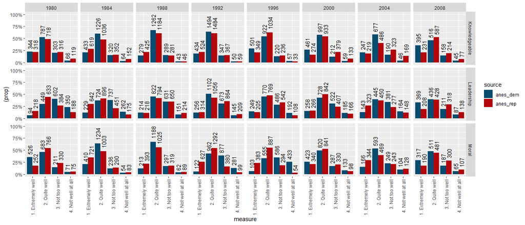

This graph allows us to explore every ranking across all the years, but it’s hard to see trends. Let’s look Instead at a line chart plotting the proportion of respondents that think a candidate exemplifies each quality extremely or quite well.

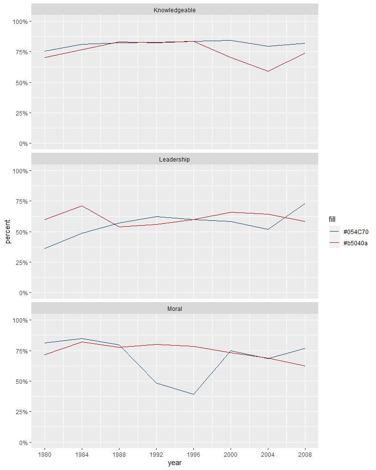

Perhaps the most interesting case is that of morals; a large hit of morals happens in the 1992 and 1966 elections. This aligns with a report for the ICPSR which named trustworthiness as the deciding factor in both those elections, a factor often associated closely with morality.

## What is the relationship between character perception and votes?

Last but not least, let’s Introduce how these perceptions impact voting outcomes. Lets start with a highlevel look at the Data.

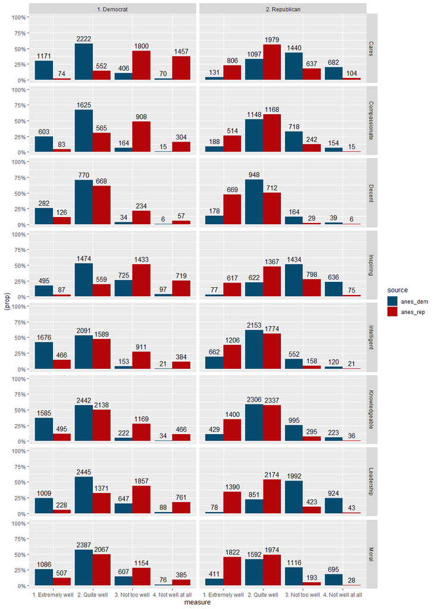

Some trends are obvious here, but with some conditional prob we can see deeper in to relationships.

```r
get_conditonal("Cares")
```

[output not shown]

This gets more interesting when you begin to compare, who a respondent does not vote for. For instance, the probability that given you think the Republican candidate is caring but you still decide to vote for the Democratic candidate is dramatically lower at 18 and 27% vice versa. This suggests that when assessing candidate voting, voters tend to gravitate towards the extremes, in other words, there are few examples when both candidates are perceived as embodying a characteristic.

That pattern follows for all traits.

```r
get_conditonal("Moral")
get_conditonal("Compassionate")
get_conditonal("Intelligent")
get_conditonal("Decent")
get_conditonal("Inspiring")
get_conditonal("Knowledgeable")
get_conditonal("Leadership")
```

[output not shown]

A final takeaway from this analysis is just how important candidate characteristics are to voting outcomes. The high and low conditional probabilities suggest that they are well connected to final voter outcomes, and can be an explanation for much of the pandering and character argument we see prevalent in elections.